# pl-01-20220216

## PL-01

## 16/02/2022

### Objetivo:

- ### TP1 - 1 - 5

### 1. Compressão de imagens bmp no formato jpeg utilizando um editor de imagem (e.g., GIMP, Adobe Photoshop, etc.).

```python
from PIL import Image

img1 = Image.open("./imagens/logo.bmp")
img1High = img1.convert("RGB")
img1High.save("./imagens/logo-high.jpg", quality=75)

img1Medium = img1.convert("RGB")
img1Medium.save("./imagens/logo-medium.jpg", quality=50)

img1Low = img1.convert("RGB")
img1Low.save("./imagens/logo-low.jpg", quality=25)
```

| original | alta (75) | média (50) | baixa (25) |
| --- | --- | --- | --- |
| 500x281 | 500x281 | 500x281 | 500x281 |
| 412Kb | 8Kb | 7Kb | 6Kb |

### 2.Crie duas funções, encoder e decoder, para encapsular as funções a desenvolver nas alíenas 3 a 9.

```python
def encoder(img, TabelaDeConversaoYCbCr, taxaDeCompressao, outrosParametros):
    return encodedImg

def decoder(img, parametrosDeConversao, outrosParametros):
    return decodedImg
```

### 3. Visualização de imagem representada pelo modelo de cor RGB.

- 3.1. Leia uma imagem .bmp, e.g., a imagem peppers.bmp.

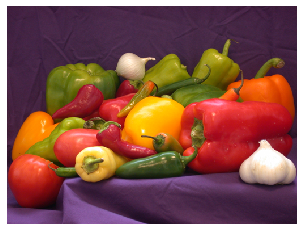

```python
import matplotlib.pyplot as plt

img = plt.imread("./imagens/peppers.bmp")

plt.figure()
plt.imshow(img)
plt.axis('off')
plt.show()
```

- 3.2. Crie uma função para implementar um colormap definido pelo utilizador.

Um *color map* converte os valores da imagem para valores especificados por uma lista.

por exemplo:

```
imagem original
```

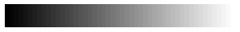

```
imagem remapeada com lista de cores
```

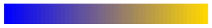

```
imagem remapeada de preto a vermelho
```

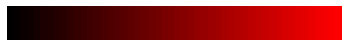

```
original
```

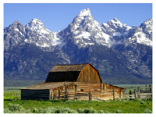

```
imagem remapeada para vermelho
```

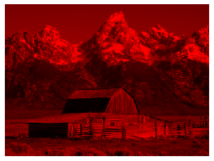

```
imagem remapeada para verde
```

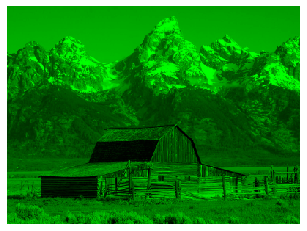

```
imagem remapeada para azul
```

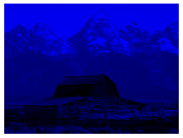

```python
import matplotlib.pyplot as plt
import matplotlib.colors as clr
import numpy as np

nl = 5;
nc = 50;
linGray = np.linspace(0., 1., nc).reshape(1, nc)
linGray = np.repeat(linGray, nl, axis=1).reshape(nc, nl).T
linGrayImg = np.zeros((nl, nc, 3))
linGrayImg[:, :, 0] = linGray
linGrayImg[:, :, 1] = linGray
linGrayImg[:, :, 2] = linGray

print("imagem original")
plt.figure()
plt.imshow(linGrayImg)
plt.axis('off')
plt.show()

colorlist=["blue", "gold"]
cm1 = clr.LinearSegmentedColormap.from_list('cmap', colorlist, N=256)
print("imagem remapeada com lista de cores")
plt.figure()
plt.imshow(linGrayImg[:, :, 0], cm1)#o parâmetro colormap só funciona se a imagem não for RGB
plt.axis('off')
plt.show()

cm2 = clr.LinearSegmentedColormap.from_list('cmap', [(0, 0, 0), (1, 0, 0)], N=256)
print("imagem remapeada de preto a vermelho")
plt.figure()
plt.imshow(linGrayImg[:, :, 0], cm2)#o parâmetro colormap só funciona se a imagem não for RGB
plt.axis('off')
plt.show()

img = plt.imread("./imagens/barn_mountains.bmp")
print("original")
plt.figure()
plt.imshow(img)
plt.axis('off')
plt.show()

redMap = clr.LinearSegmentedColormap.from_list('cmap', [(0, 0, 0), (1, 0, 0)], N=256)
print("imagem remapeada para vermelho")
plt.figure()
plt.imshow(img[:, :, 0], redMap)#o parâmetro colormap só funciona se a imagem não for RGB
plt.axis('off')
plt.show()

greenMap = clr.LinearSegmentedColormap.from_list('cmap', [(0, 0, 0), (0, 1, 0)], N=256)
print("imagem remapeada para verde")
plt.figure()
plt.imshow(img[:, :, 1], greenMap)#o parâmetro colormap só funciona se a imagem não for RGB
plt.axis('off')
plt.show()

blueMap = clr.LinearSegmentedColormap.from_list('cmap', [(0, 0, 0), (0, 0, 1)], N=256)
print("imagem remapeada para azul")
plt.figure()
plt.imshow(img[:, :, 2], blueMap)#o parâmetro colormap só funciona se a imagem não for RGB
plt.axis('off')
plt.show()
```

- ### 3.3. Crie uma função que permita visualizar a imagem com um dado colormap.
- ### 3.4. Crie uma função para separar a imagem nos seus componentes RGB. Crie também a função inversa.
- ### 3.5. Visualize a imagem e cada um dos canais RGB (com o colormap adequado).

### 4. Pré-processamento da imagem: padding.

- ### 4.1. Crie uma função para fazer padding da imagem. Caso a dimensão da imagem não seja múltipla de 16x16, faça padding da mesma, replicando a última linha e a última coluna em conformidade. Crie também a função inversa. Certifique-se de que recupera a imagem com a dimensão original, visualizando-a.

### Exemplo de padding apenas nas linhas de uma matriz:

```
dim =  (10, 10, 3)
```

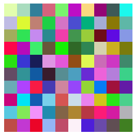

```
dim =  (16, 10, 3)
```

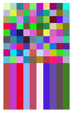

```
dim =  (10, 10, 3)
```

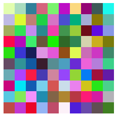

```python
import matplotlib.pyplot as plt
import matplotlib.colors as clr
import numpy as np

nl = 10
nc = 10
colors = 3

randImg = np.random.rand(nl, nc, colors)
print("dim = ", randImg.shape)
plt.figure()
plt.imshow(randImg)
plt.axis('off')
plt.show()

p1 = randImg[:, :, 0]
p2 = randImg[:, :, 1]
p3 = randImg[:, :, 2]

r, c = p1.shape
while (r%16) != 0:
    p1 = np.vstack([p1, p1[-1, :]])
    p2 = np.vstack([p2, p2[-1, :]])
    p3 = np.vstack([p3, p3[-1, :]])
    r, c = p1.shape

paddedImg = np.zeros((r, c, 3))
paddedImg[:, :, 0] = p1
paddedImg[:, :, 1] = p2
paddedImg[:, :, 2] = p3
print("dim = ", paddedImg.shape)
plt.figure()
plt.imshow(paddedImg)
plt.axis('off')
plt.show()

unpaddedImg = paddedImg[:nl, :nc, :]
print("dim = ", unpaddedImg.shape)
plt.figure()
plt.imshow(unpaddedImg)
plt.axis('off')
plt.show()
```

### 5. Conversão para o modelo cor YCbCr.

- #### 5.1. Crie uma função para converter a imagem do modelo de cor RGB para o modelo de cor YCbCr. Crie também a função inversa (conversão de YCbCr para RGB). Certifique-se de que consegue obter os valores originais de RGB (teste, por exemplo, com o pixel [0, 0]).

Nota: na conversão inversa, garanta que R, G e B sejam número inteiros no intervalo {0, 1, …, 255}.

- #### 5.2. Converta a imagem inicial para o modelo de cor YCbCr.
- #### 5.3. Visualize cada um dos canais (com o colormap adequado)
- #### 5.4. Compare a imagem de Y com R, G e B e com Cb e Cr. Tire conclusões.

### Matriz de conversão RGB -> YCbCr:

$$\begin{bmatrix} Y \\ Cb \\ Cr \end{bmatrix} = \begin{bmatrix}0.299 & 0.587 & 0.114 \\ −0.168736 & −0.331264 & 0.5\\0.5 & −0.418688 & −0.081312\end{bmatrix}\begin{bmatrix}R \\ G \\ B\end{bmatrix} - \begin{bmatrix}0\\128\\128\end{bmatrix}$$

## **NÃO UTILIZAR A TABELA DO SLIDE 37 PARA YCbCr->RGB**

## utilizar:

```python
import numpy as np

Tc = np.array([[0.299, 0.587, 0.114],
              [-0.168736, -0.331264, 0.5],
              [0.5, -0.418688, -0.081312]])

TcInvertida = np.linalg.inv(Tc)

print("Tc\n", Tc)
print()
print("TcInvertida\n", TcInvertida)
```

```
Tc
 [[ 0.299     0.587     0.114   ]
 [-0.168736 -0.331264  0.5     ]
 [ 0.5      -0.418688 -0.081312]]

TcInvertida
 [[ 1.00000000e+00 -1.21889419e-06  1.40199959e+00]
 [ 1.00000000e+00 -3.44135678e-01 -7.14136156e-01]
 [ 1.00000000e+00  1.77200007e+00  4.06298063e-07]]
```

```python
! jupyter nbconvert --to html pl-01-20220216.ipynb
```

```
[NbConvertApp] Converting notebook pl-01-20220216.ipynb to html
[NbConvertApp] Writing 479043 bytes to pl-01-20220216.html
```